# Tutorial 4: Predicting Reactor Yield Using Simple Linear and Multiple Linear Regression

CHEE4003: Special Topics A - Artificial Intelligence in Chemical Engineering

Published

October 8, 2026

# The Regression Problem

In Tutorials 2 and 3, we focused on **classification** problems, where the target variable was a category or class labely, such as a heart-disease diagnosis, a flow regime, or a pump fault status. In this tutorial, we shift our attention to **regression** problems, where the target variable is a **continuous numerical value**. Rather than predicting which *category* an observation belongs to, the goal is to predict a *quantity* that can take on a range of values.

We begin with **simple linear regression**, which uses a single feature to predict the target variable. We then extend this idea to **multiple linear regression**, which uses several features simultaneously. A key idea to notice is that these are fundamentally the *same algorithm*: multiple linear regression is simply an extension of simple linear regression that uses more feature columns.

In this tutorial, a **continuous slurry reactor** is used for the liquid-phase hydrogenation of **styrene (C₈H₈)** to **ethylbenzene (C₈H₁₀)**. Hydrogen gas is supplied under pressure and dispersed into the liquid phase, where it reacts with dissolved styrene over suspended metal catalyst particle, as shown in Figure 1. The reactor operates continuously at steady state, and product yield depends on temperature, pressure, catalyst concentration, and feed flow rate.

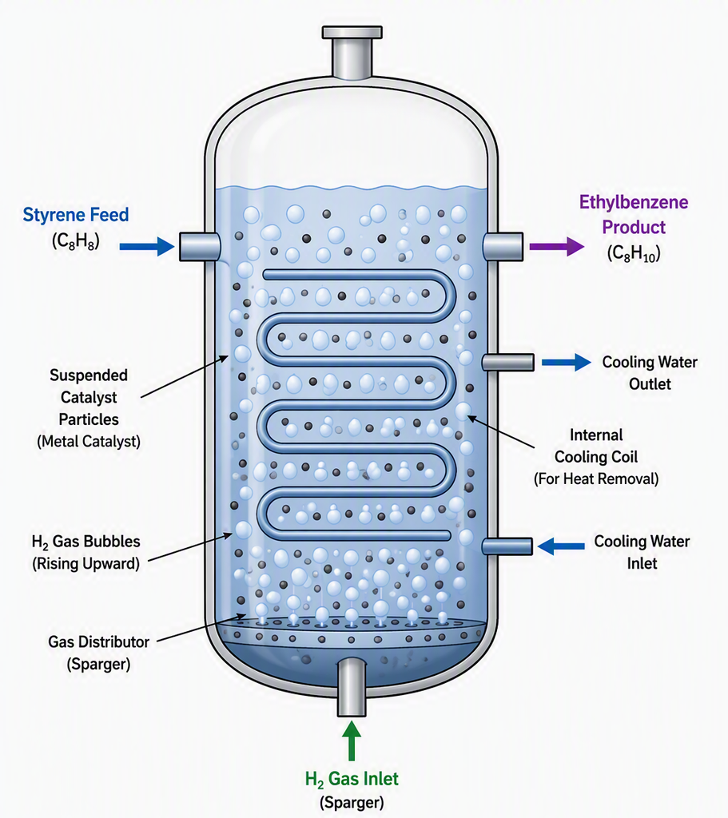

Figure 1: Continuous slurry reactor used for styrene-to-ethylbenzene hydrogenation.

To investigate how operating conditions affect reactor performance, engineers conducted **400 experimental runs** under different operating conditions. For each run, four operating variables were recorded along with the resulting **ethylbenzene yield (%)**. Our goal is to develop a predictive model that estimates **product yield** from the **operating conditions**.

Download the dataset to get started:

```
ReactionYield_Data.csv
```

```
T [°C],P [bar],C_cat [wt%],F [mol/s],Yield [%]
126.7732437,7.630090525,0.113698831,1.589586949,53.05265776
192.5695544,7.732157237,0.762324471,0.948245933,84.5126996
71.62394191,5.523658274,0.924843284,0.592470866,44.06288053
192.2974171,2.951375837,1.343198171,2.421461804,78.926404
... (397 more lines)
```

Below is a description of each of the variables in the dataset:

| Column | Description |
| --- | --- |
| T [°C] | Reactor operating temperature |
| P [bar] | Reactor operating pressure |
| C_cat [wt%] | Concentration of suspended metal catalyst particles |
| F [mol/s] | Styrene feed flowrate |
| Yield [%] | Ethylbenzene yield (**the target variable**) |

Before anything else, we need to have the correct libraries imported. Copy the following code into your script to import the necessary libraries:

```
import_libraries.py
```

```python
import numpy as np
import pandas as pd
import matplotlib.pyplot as plt
from sklearn.model_selection import train_test_split, cross_val_score
from sklearn.linear_model import LinearRegression
from sklearn.metrics import mean_absolute_error, mean_squared_error, r2_score
```

## Part A: Simple Linear Regression

We begin with the simplest possible model: predict yield from a **single feature** (input variable).

**NoteWhat is linear regression?**

Linear regression models the relationship between an input variable and an outcome by fitting the straight line that best represents the observed data. It does this by choosing the slope and intercept that minimise the **sum of squared errors**, where each error is the vertical distance between an observed value and the value predicted by the line. Because it minimises the squared errors, the method is known as **ordinary least squares (OLS)** regression.

For a single input variable, the model is

$$\hat{y} = w_0 + w_1 x$$

where $w_0$ is the **intercept** (the predicted value of $y$ when $x = 0$) and $w_1$ is the **slope** (the expected change in $y$ for a one-unit increase in $x$).

A key advantage of linear regression is that, when using the mean squared error (MSE) loss function, the optimal parameters can be obtained directly from a **closed-form solution**. Unlike many machine learning algorithms that require iterative optimisation procedures, linear regression can be fit in a single calculation, making it computationally efficient and practical even for large datasets.

### Task 1 : Load the dataset

Write a function `load_reaction_data` that loads the dataset and returns the features `X` (a DataFrame of the four operating conditions) and the target `y` (the yield). Print the shapes to confirm the data loaded correctly.

```
load_reaction_data.py
```

```python
def load_reaction_data(file_path):
    """
    Load the reaction yield dataset and return the features and target.

    Parameters
    ----------
    file_path : str
        The path to the CSV file containing the dataset.

    Returns
    -------
    X : pd.DataFrame
        A DataFrame of the four operating conditions (T, P, C_cat, F).
    y : pd.Series
        The measured product yield.
    """
```

When you run this function, it should yield the following output:

X, y = load_reaction_data('data/ReactionYield_Data.csv')

Features shape: (400, 4)

Target shape: (400,)

Features: ['T [°C]', 'P [bar]', 'C_cat [wt%]', 'F [mol/s]']

**Callout-answer**Answer**

```
load_reaction_data.py
```

```python
def load_reaction_data(file_path):
    """
    Load the reaction yield dataset and return the features and target.

    Parameters
    ----------
    file_path : str
        The path to the CSV file containing the dataset.

    Returns
    -------
    X : pd.DataFrame
        A DataFrame of the four operating conditions (T, P, C_cat, F).
    y : pd.Series
        The measured product yield.
    """
    # Load the dataset (utf-8-sig strips the byte-order mark on the first column)
    data = pd.read_csv(file_path, encoding="utf-8-sig")

    # Features: the four operating conditions. Target: the measured yield.
    X = data.drop(columns=["Yield [%]"])
    y = data["Yield [%]"]

    print(f"Features shape: {X.shape}")
    print(f"Target shape:   {y.shape}")
    print(f"Features: {list(X.columns)}")
    return X, y

X, y = load_reaction_data('data/ReactionYield_Data.csv')
```

Output

```
Features shape: (400, 4)
Target shape:   (400,)
Features: ['T [°C]', 'P [bar]', 'C_cat [wt%]', 'F [mol/s]']
```

### Task 2 : Explore the dataset

Once the dataset has been loaded, the next step is to explore its structure and gain a better understanding of both the reactor operating conditions and the product yield measurements. In Tutorials 2 and 3, you learned how to use the `.head()` and `.describe()` methods to inspect a dataset and summarise its key characteristics.

Using the code from those tutorials as a starting point, write a function called `explore_data`. The function should first display the first few rows of the feature variables (`X`) and the target variable (`y`) using `.head()`. This provides a quick overview of the data and helps verify that it has been loaded correctly.

Next, use `.describe()` to generate summary statistics for the reactor operating variables, including measures such as the mean, standard deviation, minimum, maximum, and quartile values. These statistics provide insight into the range and variability of the operating conditions.

Finally, generate summary statistics for the target variable, **Yield [%]**, using `.describe()`. Examining the distribution of the target variable before training a predictive model can help identify potential issues such as limited variability, extreme values, or unusual observations.

```
explore_data.py
```

```python
def explore_data(X, y):
    """
    Explore a dataset by displaying first 5 rows and summary statistics
    for both the input features and the target variable.

    Parameters
    ----------
    X : pd.DataFrame
        A Pandas DataFrame containing the input features.

    y : pd.Series
        A Pandas Series containing the target variable.

    Returns
    -------
    None
        Prints the first five rows of the feature matrix and target variable,
        along with summary statistics for both.
    """
```

Here is what your function should output:

explore_data(X, y)

First 5 rows of features:

T [°C] P [bar] C_cat [wt%] F [mol/s]

0 126.773244 7.630091 0.113699 1.589587

1 192.569554 7.732157 0.762324 0.948246

2 71.623942 5.523658 0.924843 0.592471

3 192.297417 2.951376 1.343198 2.421462

4 96.774718 5.979583 0.803865 0.708795

First 5 rows of target:

0 53.052658

1 84.512700

2 44.062881

3 78.926404

4 56.342566

Name: Yield [%], dtype: float64

Summary statistics of features:

T [°C] P [bar] C_cat [wt%] F [mol/s]

count 400.000000 400.000000 400.000000 400.000000

mean 122.989492 4.632165 0.827365 1.712823

std 42.923178 2.039536 0.402025 0.724214

min 50.412072 1.014398 0.107736 0.500240

25% 87.525408 2.903125 0.489063 1.071122

50% 121.568261 4.560280 0.827051 1.748325

75% 161.977366 6.540205 1.164677 2.307418

max 199.853882 7.989912 1.499708 2.992094

Summary statistics of target:

count 400.000000

mean 60.010037

std 14.637695

min 28.040946

25% 49.092334

50% 59.623764

75% 71.003429

max 98.945972

Name: Yield [%], dtype: float64

**Callout-answer**Answer**

```
explore_data.py
```

```python
def explore_data(X, y):
    """
    Explore a dataset by displaying first 5 rows and summary statistics
    for both the input features and the target variable.

    Parameters
    ----------
    X : pd.DataFrame
        A Pandas DataFrame containing the input features.

    y : pd.Series
        A Pandas Series containing the target variable.

    Returns
    -------
    None
        Prints the first five rows of the feature matrix and target variable,
        along with summary statistics for both.
    """

    print("First 5 rows of features:")
    print(X.head())

    print("First 5 rows of target:")
    print(y.head())

    print("Summary statistics of features:")
    print(X.describe())

    print("Summary statistics of target:")
    print(y.describe())

explore_data(X, y)
```

Output

```
First 5 rows of features:
       T [°C]   P [bar]  C_cat [wt%]  F [mol/s]
0  126.773244  7.630091     0.113699   1.589587
1  192.569554  7.732157     0.762324   0.948246
2   71.623942  5.523658     0.924843   0.592471
3  192.297417  2.951376     1.343198   2.421462
4   96.774718  5.979583     0.803865   0.708795
First 5 rows of target:
0    53.052658
1    84.512700
2    44.062881
3    78.926404
4    56.342566
Name: Yield [%], dtype: float64
Summary statistics of features:
           T [°C]     P [bar]  C_cat [wt%]   F [mol/s]
count  400.000000  400.000000   400.000000  400.000000
mean   122.989492    4.632165     0.827365    1.712823
std     42.923178    2.039536     0.402025    0.724214
min     50.412072    1.014398     0.107736    0.500240
25%     87.525408    2.903125     0.489063    1.071122
50%    121.568261    4.560280     0.827051    1.748325
75%    161.977366    6.540205     1.164677    2.307418
max    199.853882    7.989912     1.499708    2.992094
Summary statistics of target:
count    400.000000
mean      60.010037
std       14.637695
min       28.040946
25%       49.092334
50%       59.623764
75%       71.003429
max       98.945972
Name: Yield [%], dtype: float64
```

### Task 3 : Find the strongest predictor

In Tutorial 1, you learned how to create scatter plots and calculate correlation coefficients to investigate relationships between variables. We can apply the same approach here to explore how the reactor operating conditions influence the product yield.

Write a function called `plot_feature_relationships` that creates a scatter plot of **Yield [%]** against each of the four input features:

- **T**: Reactor temperature
- **P**: Reactor pressure
- **C_cat**: Catalyst concentration
- **F**: Feed flow rate

For each feature, plot the observed values against **Yield [%]** and calculate the **Pearson correlation coefficient** ($r$) to quantify the strength and direction of the linear relationship. Display the value of *r* on each plot (or in the plot title) so that the relationship can be interpreted visually and quantitatively.

Recall that:

- $r \approx 1$ indicates a strong positive linear relationship.
- $r \approx -1$ indicates a strong negative linear relationship.
- $r \approx 0$ indicates little or no linear relationship.

Examining these plots and correlation coefficients before model development can help identify the most influential operating variables and provide insight into whether a linear model is likely to be appropriate.

```
plot_feature_relationships.py
```

```python
def plot_feature_relationships(X, y):
    """
    Plot Yield [%] against each feature and display the
    correlation coefficient (r).

    Parameters
    ----------
    X : pd.DataFrame
        Input features.
    y : pd.Series
        Yield [%] values.
    """
```

plot_feature_relationships(X, y)

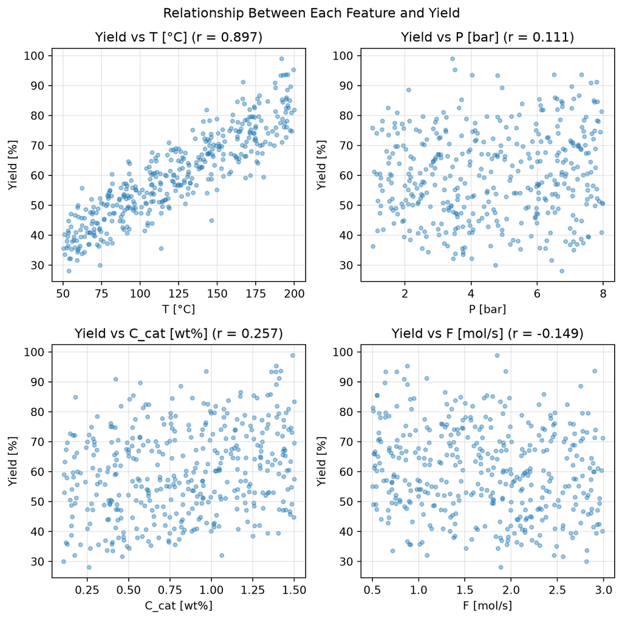

Notice that reactor temperature (**T**) has by far the strongest linear relationship with yield, with a correlation coefficient $r$ close to 0.9. This indicates a strong positive relationship between **T** and **Yield [%]**, where higher temperatures tend to produce higher yields. Because temperature appears to be the most informative single predictor, we will use **T** as the sole input variable for the linear regression model developed in **Part A**.

**Callout-answer**Answer**

```
plot_feature_relationships.py
```

```python
def plot_feature_relationships(X, y):
    """
    Plot Yield [%] against each feature and display the
    correlation coefficient (r).

    Parameters
    ----------
    X : pd.DataFrame
        Input features.
    y : pd.Series
        Yield [%] values.
    """
    # Create a subplot for each feature.
    fig, axes = plt.subplots(2, 2, figsize=(8, 8))
    axes = axes.flatten()

    # Plot each feature against yield.
    for i, feature in enumerate(X.columns):
        axes[i].scatter(X[feature], y, alpha=0.4, s=12)

        # Calculate the correlation coefficient.
        r = X[feature].corr(y)

        # Add labels and correlation value.
        axes[i].set_xlabel(feature)
        axes[i].set_ylabel("Yield [%]")
        axes[i].set_title(f"Yield vs {feature} (r = {r:.3f})")
        axes[i].grid(True, alpha=0.3)

    # Format and display the figure.
    plt.suptitle("Relationship Between Each Feature and Yield")
    plt.tight_layout()
    plt.show()

plot_feature_relationships(X, y)
```

Output

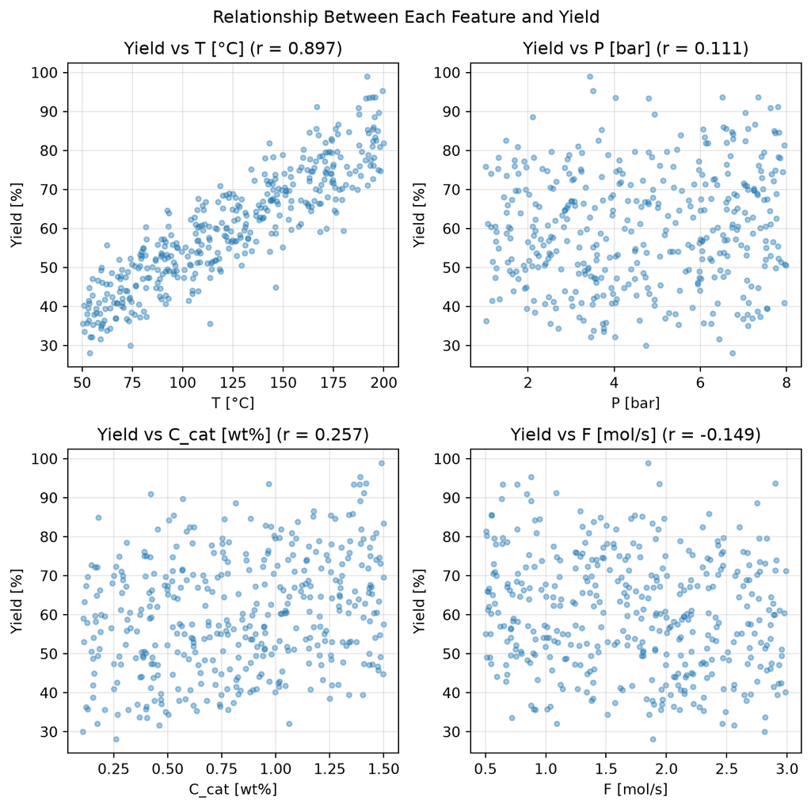

### Task 4 : Split into training and testing sets

Unlike previous tutorials, where the data were divided into **70% training**, **15% validation**, and **15% testing** sets, in this tutorial we will use a simpler **80/20 train-test split**. The training set will later be used for **k-fold cross-validation**, allowing us to estimate model performance and tune model parameters without the need for a separate validation set. The testing set will be reserved for the final evaluation on unseen data.

Write a function `preprocess_data` that uses `train_test_split` to divide the features and target into training and testing sets, using a `test_size` of `0.2` and a `random_state` of `42`. Since this is a regression problem with a continuous target variable, **no stratification is required**, so `train_test_split` can be used without the `stratify` argument. We retain all four feature columns and use the same training and testing samples throughout the tutorial so that different regression models can be compared fairly in Parts A and B.

```
preprocess_data.py
```

```python
def preprocess_data(X, y, test_size=0.2, random_state=42):
    """
    Split the features and target into training and testing sets.

    Parameters
    ----------
    X : pd.DataFrame
        The feature DataFrame.
    y : pd.Series
        The target.
    test_size : float, optional
        The proportion of the data to hold back for testing (default is 0.2).
    random_state : int, optional
        The random seed for reproducibility (default is 42).

    Returns
    -------
    X_train, X_test, y_train, y_test
        The training and testing features and targets.
    """
    return X_train, X_test, y_train, y_test
```

X_train, X_test, y_train, y_test = preprocess_data(X, y)

X_train.shape, X_test.shape, y_train.shape, y_test.shape

((320, 4), (80, 4), (320,), (80,))

**Callout-answer**Answer**

```
preprocess_data.py
```

```python
def preprocess_data(X, y, test_size=0.2, random_state=42):
    """
    Split the features and target into training and testing sets.

    Parameters
    ----------
    X : pd.DataFrame
        The feature DataFrame.
    y : pd.Series
        The target.
    test_size : float, optional
        The proportion of the data to hold back for testing (default is 0.2).
    random_state : int, optional
        The random seed for reproducibility (default is 42).

    Returns
    -------
    X_train, X_test, y_train, y_test
        The training and testing features and targets.
    """
    X_train, X_test, y_train, y_test = train_test_split(X, y, test_size=test_size, random_state=random_state)
    return X_train, X_test, y_train, y_test

X_train, X_test, y_train, y_test = preprocess_data(X, y)
print(X_train.shape, X_test.shape, y_train.shape, y_test.shape)
```

Output

```
(320, 4) (80, 4) (320,) (80,)
```

### Task 5 : Train a simple linear regression model

Write a function `train_linear_regression` that fits a `LinearRegression` model using the feature(s) provided and returns the trained model. We will reuse this function throughout the tutorial for both simple and multiple linear regression.

In **Part A**, train the model using only the **Temperature** feature. Once the model has been fitted, extract the slope and intercept coefficients and use them to write down the resulting linear regression equation. This will allow us to interpret how changes in temperature affect the predicted product yield.

**TipReading off the fitted parameters**

After you call `.fit`, scikit-learn stores the learned parameters on the model. `model.intercept_` is the intercept $w_0$ (a single number), and `model.coef_` is the array of slopes, one per feature. For a single-feature model the slope is `model.coef_[0]`. You can evaluate how well the fitted model explains the variation in the target variable using the coefficient of determination, **R²**, which can be obtained with `model.score(X, y)`. See the [scikit-learn documentation](https://scikit-learn.org/stable/modules/generated/sklearn.linear_model.LinearRegression.html).

```
train_linear_regression.py
```

```python
def train_linear_regression(X_train, y_train):
    """
    Fit a linear regression model to the training data.

    Parameters
    ----------
    X_train : pd.DataFrame
        The training features (one or more columns).
    y_train : pd.Series
        The training target.

    Returns
    -------
    model : LinearRegression
        The fitted linear regression model.
    """
    return model
```

Selecting a single column with double brackets (`X_train[["T [°C]"]]`) ensures that the result remains a **2D DataFrame** rather than a 1D Series. Scikit-learn expects the input features to have shape `(n_samples, n_features)`, even when only a single feature is used. Therefore, using double brackets is necessary when fitting a simple linear regression model with temperature as the sole predictor.

When you run the code, you should obtain the following output:

feature = "T [°C]"

simple_model = train_linear_regression(X_train[[feature]], y_train)

print(f"Slope (w1): {simple_model.coef_[0]:.3f}")

Slope (w1): 0.304

print(f"Intercept (w0): {simple_model.intercept_:.3f}")

Intercept (w0): 22.600

print(f"Fitted model: Yield = {simple_model.intercept_:.2f} + {simple_model.coef_[0]:.3f} * T")

Fitted model: Yield = 22.60 + 0.304 * T

**Callout-answer**Answer**

```
train_linear_regression.py
```

```python
def train_linear_regression(X_train, y_train):
    """
    Fit a linear regression model to the training data.

    Parameters
    ----------
    X_train : pd.DataFrame
        The training features (one or more columns).
    y_train : pd.Series
        The training target.

    Returns
    -------
    model : LinearRegression
        The fitted linear regression model.
    """
    model = LinearRegression()
    model.fit(X_train, y_train)
    return model

feature = "T [°C]"
simple_model = train_linear_regression(X_train[[feature]], y_train)
print(f"Slope (w1):     {simple_model.coef_[0]:.3f}")
print(f"Intercept (w0): {simple_model.intercept_:.3f}")
print(f"Fitted model: Yield = {simple_model.intercept_:.2f} + {simple_model.coef_[0]:.3f} * T")
```

Output

```
Slope (w1):     0.304
Intercept (w0): 22.600
Fitted model: Yield = 22.60 + 0.304 * T
```

### Task: 6 Model validation using K-Fold cross-validation

Evaluating a model on a single train-test split can produce results that depend on the particular samples selected for training and validation. A more reliable approach is **k-fold cross-validation**, which evaluates the model on multiple train-validation splits.

Write a function `cross_validate_model` that evaluates a linear regression model using the **coefficient of determination ($R^2$)** and **5-fold cross-validation** (`cv=5`). Report the $R^2$ score for each fold, together with the mean and standard deviation across all folds.

Unlike the **Pearson correlation coefficient** ($r$), which measures the strength of a linear relationship between two variables, **$R^2$ measures how much of the variation in the target variable is explained by the model**.

As a guide:

- $R^2 \approx 1$: Excellent fit
- $R^2 > 0.7$: Strong predictive performance
- $R^2 \approx 0.5$: Moderate predictive performance
- $R^2 < 0$: Worse than predicting the mean

The mean $R^2$ indicates the model’s expected performance, while the standard deviation shows how consistent that performance is across different folds.

**NoteWhy cross-validate?**

In k-fold cross-validation, the training set is divided into `k` approximately equal-sized folds. The model is trained and evaluated `k` times. During each iteration, one fold is held out for validation while the remaining `k-1` folds are used for training. This process continues until every fold has served as the validation set exactly once. Averaging the `k` scores gives a more trustworthy estimate of how the model generalises, and the spread of the scores tells you how sensitive the model is to the particular split. This basically is how we determine a confidence interval for the model’s performance.

**TipRunning k-fold CV in one call**

```
cross_validate_model.py
```

```python
def cross_validate_model(model, X, y, cv=5, scoring="r2"):
    """
    Estimate model performance using k-fold cross-validation.

    Parameters
    ----------
    model : sklearn estimator
        The model to evaluate.
    X : pd.DataFrame
        The feature set.
    y : pd.Series
        The target variable.
    cv : int, optional
        The number of folds (default is 5).
    scoring : str, optional
        The performance metric used to evaluate the model
        (default is "r2").

    Returns
    -------
    scores : np.ndarray
        The cross-validation scores for the chosen metric,
        one value per fold.
    """
    return scores
```

Notice that the `cross_validate_model` function is intentionally **general**. It accepts any **unfitted scikit-learn model** and any valid `scoring` metric, making it reusable for a wide range of machine learning problems.

feature = "T [°C]"

model=LinearRegression()

cv_scores = cross_validate_model(model, X_train[[feature]], y_train, cv=5, scoring="r2")

Fold 1: R2 = 0.803

Fold 2: R2 = 0.832

Fold 3: R2 = 0.839

Fold 4: R2 = 0.702

Fold 5: R2 = 0.822

Mean R2: 0.800 +/- 0.050

What does the spread of the scores tell you about the model’s sensitivity to the particular train/test split?

**Callout-answer**Answer**

```
cross_validate_model.py
```

```python
def cross_validate_model(model, X, y, cv=5, scoring="r2"):
    """
    Estimate model performance using k-fold cross-validation.

    Parameters
    ----------
    model : sklearn estimator
        The model to evaluate.
    X : pd.DataFrame
        The feature set.
    y : pd.Series
        The target variable.
    cv : int, optional
        The number of folds (default is 5).
    scoring : str, optional
        The performance metric used to evaluate the model
        (default is "r2").

    Returns
    -------
    scores : np.ndarray
        The cross-validation scores for the chosen metric,
        one value per fold.
    """
    scores = cross_val_score(model, X, y, cv=cv, scoring="r2")

    for i, score in enumerate(scores, start=1):
        print(f"  Fold {i}: R2 = {score:.3f}")
    print(f"Mean R2: {scores.mean():.3f} +/- {scores.std():.3f}")
    return scores

feature = "T [°C]"
model=LinearRegression()
cv_scores = cross_validate_model(model, X_train[[feature]], y_train, cv=5, scoring="r2")
```

Output

```
  Fold 1: R2 = 0.803
  Fold 2: R2 = 0.832
  Fold 3: R2 = 0.839
  Fold 4: R2 = 0.702
  Fold 5: R2 = 0.822
Mean R2: 0.800 +/- 0.050
```

The model achieved a mean **R²** of **0.800 ± 0.050**, indicating that temperature alone explains approximately **80% of the variability in ethylbenzene yield**. The relatively small standard deviation across the folds suggests that the model performs consistently across different subsets of the training data and is not overly sensitive to the particular samples included in each split. Overall, these results indicate that temperature is a strong predictor of yield and that the fitted linear relationship generalises well across the training dataset.

### Task 7 : Plot the fitted line

Given the consistent performance observed across the cross-validation folds, we can now visualise the fitted relationship learned from the **training data**. With only a single predictor, the entire model can be displayed on a single plot. Write a function `plot_regression_line()` that scatters the training observations (yield versus temperature) and overlays the fitted regression line.

```
plot_regression_line.py
```

```python
def plot_regression_line(model, X, y, feature):
    """
    Scatter the data and overlay the fitted regression line (single-feature models only).

    Parameters
    ----------
    model : fitted LinearRegression
        A model trained on the single column named by `feature`.
    X : pd.DataFrame
        The features to scatter.
    y : pd.Series
        The target to scatter.
    feature : str
        The name of the feature column to plot on the x-axis.

    Returns
    -------
    None
        Displays a scatter plot with the fitted regression line.
"""
```

plot_regression_line(simple_model, X_train, y_train, feature)

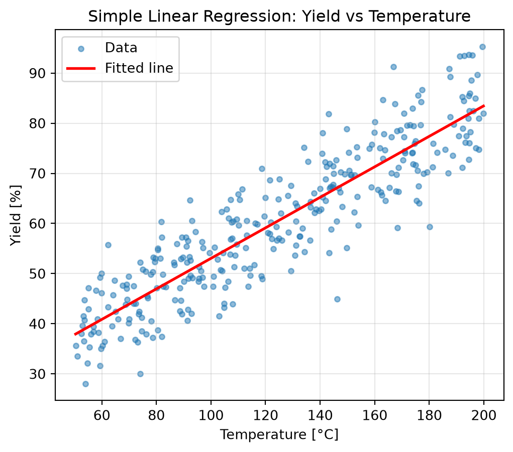

Does the fitted line capture the overall trend in the training data?

**Callout-answer**Answer**

```
plot_regression_line.py
```

```python
def plot_regression_line(model, X, y, feature):
    """
    Scatter the data and overlay the fitted regression line (single-feature models only).

    Parameters
    ----------
    model : fitted LinearRegression
        A model trained on the single column named by `feature`.
    X : pd.DataFrame
        The features to scatter.
    y : pd.Series
        The target to scatter.
    feature : str
        The name of the feature column to plot on the x-axis.

    Returns
    -------
    None
        Displays a scatter plot with the fitted regression line.
    """
    plt.figure(figsize=(6, 5))
    plt.scatter(X[feature], y, alpha=0.5, s=15, label="Data")

    # Evaluate the fitted line across the range of the feature
    x_line = np.linspace(X[feature].min(), X[feature].max(), 100)
    y_line = model.predict(pd.DataFrame({feature: x_line}))
    plt.plot(x_line, y_line, color="red", linewidth=2, label="Fitted line")

    plt.xlabel("Temperature [°C]")
    plt.ylabel("Yield [%]")
    plt.title("Simple Linear Regression: Yield vs Temperature")
    plt.legend()
    plt.grid(True, alpha=0.3)
    plt.show()

plot_regression_line(simple_model, X_train, y_train, feature)
```

Output

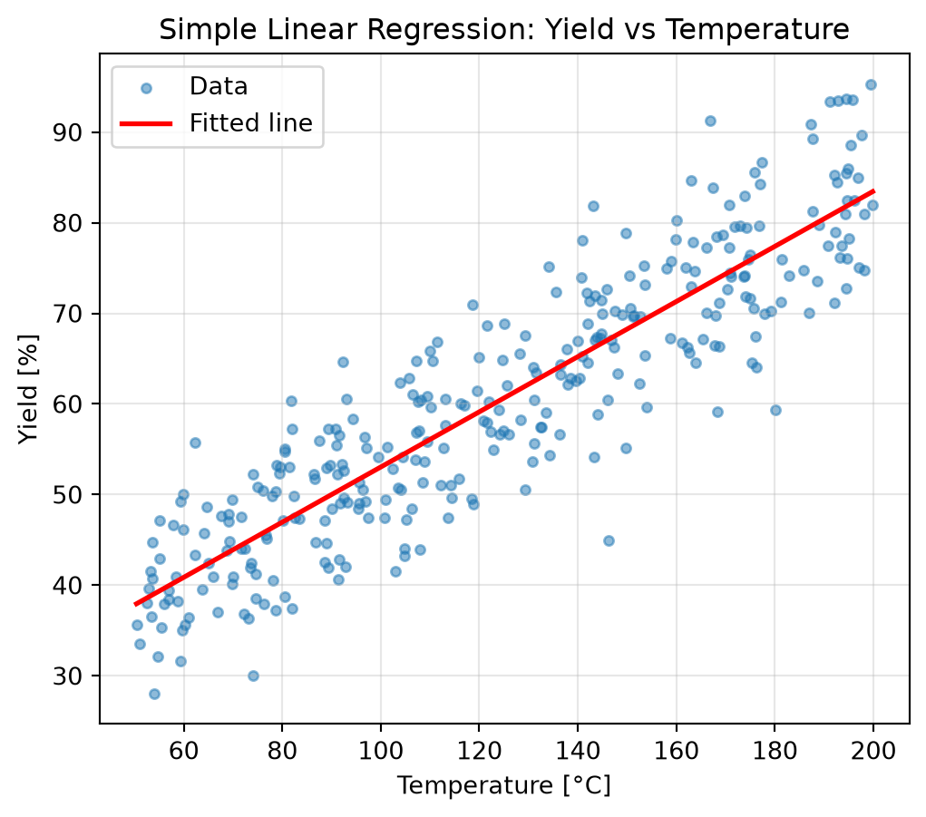

The fitted line captures the overall positive relationship between temperature and yield, indicating that higher temperatures generally lead to higher yields. The data points are reasonably clustered around the line, suggesting that a linear model is a suitable first approximation. However, there is still noticeable scatter around the line, meaning temperature does not explain all of the variation in yield. Other operating variables and random process variability likely contribute to the remaining prediction error.

### Task 8 : Evaluate the model performance on the testing set

A classification model was scored by counting correct predictions; a regression model is scored by measuring how *far* its predictions fall from the true values. Write a function `evaluate_regression` that predicts on the test set and reports four standard metrics: MAE, MSE, RMSE, and R².

**NoteRegression metrics**

| Metric | Equation | Meaning |
| --- | --- | --- |
| **MAE** (Mean Absolute Error) | $\displaystyle \text{MAE} = \frac{1}{n}\sum_{i=1}^{n}\left\|y_i-\hat{y}_i\right\|$ | The average magnitude of the prediction error, expressed in the **same units as the target variable**. MAE is easy to interpret because it corresponds directly to the typical absolute prediction error… |
| **MSE** (Mean Squared Error) | $\displaystyle \text{MSE} = \frac{1}{n}\sum_{i=1}^{n}\left(y_i-\hat{y}_i\right)^2$ | The average of the **squared** prediction errors. Squaring gives greater weight to larger errors. The units are the **square of the target variable units** (e.g., kg$^2$, °C$^2$, or %$^2$). |
| **RMSE** (Root Mean Squared Error) | $\displaystyle \text{RMSE} = \sqrt{\frac{1}{n}\sum_{i=1}^{n}\left(y_i-\hat{y}_i\right)^2}$ | The square root of MSE, expressed in the **original units of the target variable** (e.g., kg, °C, or %). RMSE is often interpreted as the typical prediction error and is more sensitive to large errors… |
| **R²** (Coefficient of Determination) | $\displaystyle R^2 = 1-\frac{\sum_{i=1}^{n}(y_i-\hat{y}_i)^2}{\sum_{i=1}^{n}(y_i-\bar{y})^2}$ | The proportion of the variance in the target variable explained by the model. $R^2 = 1$ indicates a perfect fit, $R^2 = 0$ indicates performance equivalent to predicting the mean, and negative values … |

**TipThe metric functions**

scikit-learn provides each metric as a function in `sklearn.metrics`, always with the true values first and the predictions second: `mean_absolute_error(y_true, y_pred)`, `mean_squared_error(y_true, y_pred)`, and `r2_score(y_true, y_pred)`. There is no separate RMSE function in older versions, so compute it directly as `np.sqrt(mean_squared_error(...))`.

```
evaluate_regression.py
```

```python
def evaluate_regression(model, X_test, y_test):
    """
    Evaluate a regression model on the test set using
    common regression metrics.

    Parameters
    ----------
    model : fitted regression model
        The trained model to evaluate.
    X_test : pd.DataFrame
        Test features.
    y_test : pd.Series
        True target values for the test set.

    Returns
    -------
    mae : float
        Mean Absolute Error.
    mse : float
        Mean Squared Error.
    rmse : float
        Root Mean Squared Error.
    r2 : float
        Coefficient of determination (R²).
    """
    return mae, mse, rmse, r2
```

simple_metrics = evaluate_regression(simple_model, X_test[[feature]], y_test)

MAE: 5.244

MSE: 44.493

RMSE: 6.670

R2: 0.786

Based on the values of **MAE**, **RMSE**, and **R$^2$** , do you think this model predicts yield well?

**Callout-answer**Answer**

```
evaluate_regression.py
```

```python
def evaluate_regression(model, X_test, y_test):
    """
    Evaluate a regression model on the test set using
    common regression metrics.

    Parameters
    ----------
    model : fitted regression model
        The trained model to evaluate.
    X_test : pd.DataFrame
        Test features.
    y_test : pd.Series
        True target values for the test set.

    Returns
    -------
    mae : float
        Mean Absolute Error.
    mse : float
        Mean Squared Error.
    rmse : float
        Root Mean Squared Error.
    r2 : float
        Coefficient of determination (R²).
    """
    y_pred = model.predict(X_test)
    mae = mean_absolute_error(y_test, y_pred)
    mse = mean_squared_error(y_test, y_pred)
    rmse = np.sqrt(mse)
    r2 = r2_score(y_test, y_pred)
    print(f"MAE:  {mae:.3f}")
    print(f"MSE:  {mse:.3f}")
    print(f"RMSE: {rmse:.3f}")
    print(f"R2:   {r2:.3f}")
    return mae, mse, rmse, r2

simple_metrics = evaluate_regression(simple_model, X_test[[feature]], y_test)
```

Output

```
MAE:  5.244
MSE:  44.493
RMSE: 6.670
R2:   0.786
```

The model performs well on unseen test data, with an **R² of 0.786**, indicating that it explains **78.6% of the variation in yield**. The **MAE (5.24%)** and **RMSE (6.67%)** suggest that predictions are typically within **5-7%** of the true yield. Overall, reactor temperature is a strong predictor of yield, although some variation remains unexplained.

### Task 9 : Plot actual vs predicted for the testing set

Drawing the fitted line only works when there is a single feature. In Part B, we will have four, so we need a way to visualise a model’s accuracy that does not depend on the number of features. The **actual-vs-predicted** (or parity) plot does exactly that. Write a function `plot_actual_vs_predicted` that scatters the predicted yield against the actual yield for the testing set, with a dashed diagonal showing where perfect predictions would land.

**TipDrawing the y = ŷ reference line**

The diagonal “perfect prediction” line runs from the smallest to the largest value that appears on either axis. Compute those limits, then draw the line with `plt.plot(lims, lims, "b--")` where `lims = [low, high]`. Adding `plt.axis("equal")` forces the same scale on both axes so the diagonal sits at 45°.

```
plot_actual_vs_predicted.py
```

```python
def plot_actual_vs_predicted(model, X_test, y_test):
    """
    Scatter predicted against actual values with a y = y-hat reference line.

    Parameters
    ----------
    model : fitted regression model
        The model to evaluate.
    X_test : pd.DataFrame
        The testing features (the same columns the model was trained on).
    y_test : pd.Series
        The testing target.

    Returns
    -------
    None
        Displays a scatter plot of actual versus predicted values.
    """
```

plot_actual_vs_predicted(simple_model, X_test[[feature]], y_test)

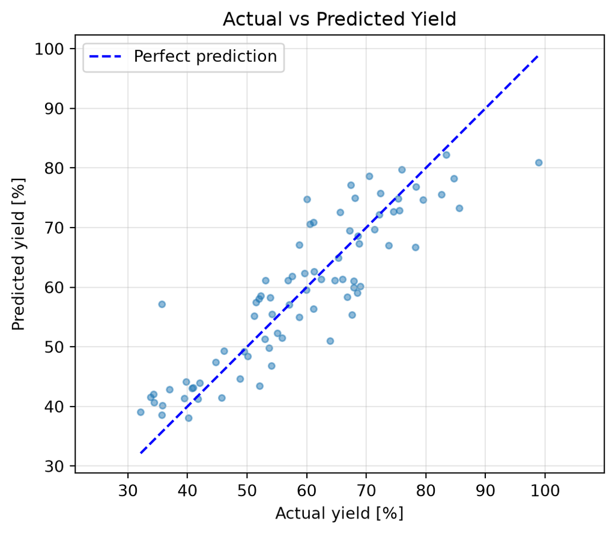

In the actual vs predicted plot, most points lie close to the dashed *perfect prediction* line. What does this indicate about the model’s performance on the test data?

**NoteReading an actual-vs-predicted plot**

Each point is one test run: its actual yield on the x-axis and the model’s prediction on the y-axis. The dashed line is where a perfect prediction would land. Points above the line are over-predictions and points below are under-predictions. The tighter the cloud hugs the line, the better the model.

**Callout-answer**Answer**

```
plot_actual_vs_predicted.py
```

```python
def plot_actual_vs_predicted(model, X_test, y_test):
    """
    Scatter predicted against actual values with a y = y-hat reference line.

    Parameters
    ----------
    model : fitted regression model
        The model to evaluate.
    X_test : pd.DataFrame
        The testing features (the same columns the model was trained on).
    y_test : pd.Series
        The testing target.

    Returns
    -------
    None
        Displays a scatter plot of actual versus predicted values.
    """
    y_pred = model.predict(X_test)

    plt.figure(figsize=(6, 5))
    plt.scatter(y_test, y_pred, alpha=0.5, s=15)

    # Dashed diagonal: where predicted would equal actual
    lims = [min(y_test.min(), y_pred.min()), max(y_test.max(), y_pred.max())]
    plt.plot(lims, lims, "b--", label="Perfect prediction")

    plt.xlabel("Actual yield [%]")
    plt.ylabel("Predicted yield [%]")
    plt.title("Actual vs Predicted Yield")
    plt.legend()
    plt.grid(True, alpha=0.3)
    plt.axis("equal")
    plt.show()

plot_actual_vs_predicted(simple_model, X_test[[feature]], y_test)
```

Output

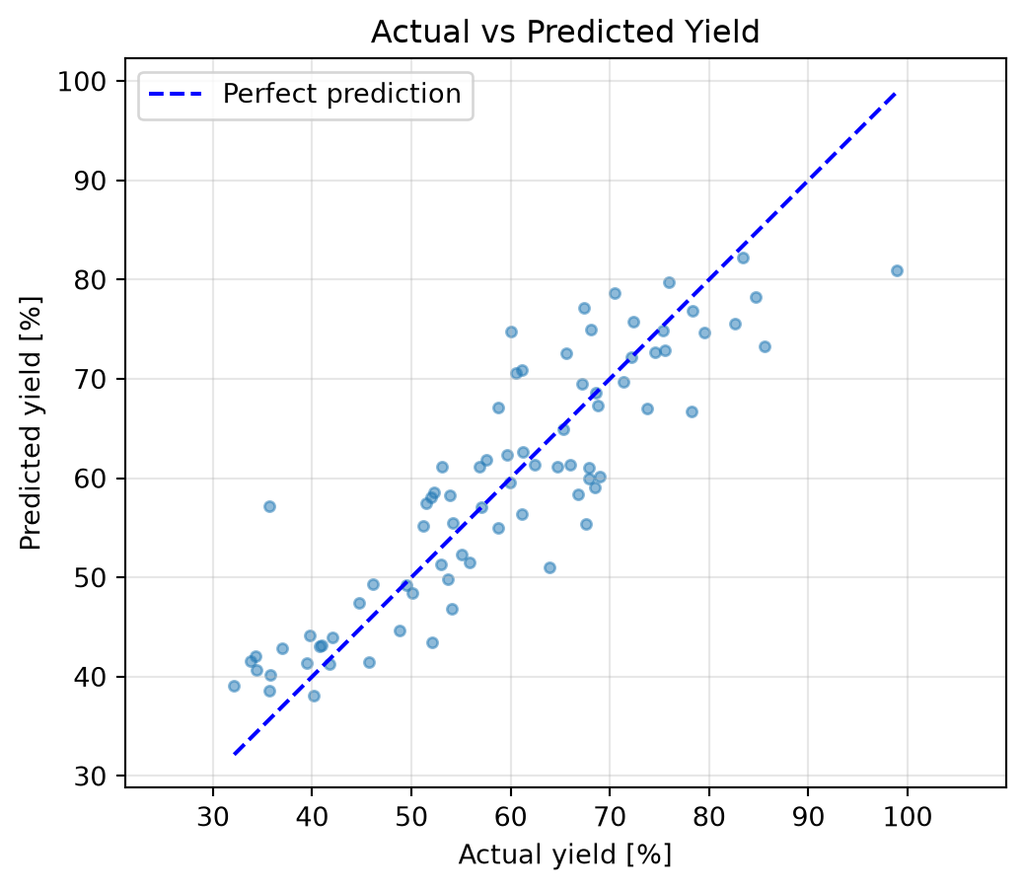

Points close to the perfect prediction line indicate that the predicted yields are similar to the actual yields. Since most points are reasonably close to the line, the model performs well on unseen test data. However, the scatter around the line shows that some prediction errors remain, meaning the model is not perfect.

## Part B: Multiple Linear Regression

In Part A, we used **temperature** as the sole predictor of yield. While this model performed reasonably well, it still left some of the variation in yield unexplained. Since reactor performance is influenced by multiple operating conditions, we can improve the model by incorporating **all four input features** simultaneously.

The model becomes

$$\hat{y} = w_0 + w_1T + w_2P + w_3C_{\mathrm{cat}} + w_4F$$

where each coefficient represents the contribution of a different operating variable to the predicted yield. The **sign** of a coefficient indicates whether increasing the corresponding variable increases (**positive coefficient**) or decreases (**negative coefficient**) the predicted yield. The **magnitude** of a coefficient indicates the strength of that effect, although coefficients should only be compared directly when the variables are measured on similar scales and units.

This approach is known as **multiple linear regression**. Like simple linear regression, it determines the coefficients by minimising the sum of squared errors between the predicted and observed yields. The key difference is that the model can now account for the combined effects of temperature, pressure, catalyst concentration, and feed flow rate, potentially leading to more accurate predictions.

### Task 10 : Fit the multiple regression model

Reuse the `train_linear_regression` function from Part A, but this time pass it the **whole** training feature set instead of a single column. Then print each fitted coefficient next to its feature name, along with the intercept.

multiple_model = train_linear_regression(X_train, y_train)

print("Coefficients:")

Coefficients:

for feature_name, coef in zip(X_train.columns, multiple_model.coef_):

print(f" {feature_name:12s}: {coef:+.3f}")

T [°C] : +0.302

P [bar] : +0.991

C_cat [wt%] : +7.237

F [mol/s] : -2.049

print(f"Intercept: {multiple_model.intercept_:.3f}")

Intercept: 15.762

Every feature now has its own coefficient. Notice that the same `train_linear_regression` function handled both the one-feature and the four-feature case without any change.

**Callout-answer**Answer**

```python
# Reuses train_linear_regression from Part A, now with all four feature columns.
multiple_model = train_linear_regression(X_train, y_train)
print("Coefficients:")
for feature_name, coef in zip(X_train.columns, multiple_model.coef_):
    print(f"  {feature_name:12s}: {coef:+.3f}")
print(f"Intercept: {multiple_model.intercept_:.3f}")
```

Output

```
Coefficients:
  T [°C]      : +0.302
  P [bar]     : +0.991
  C_cat [wt%] : +7.237
  F [mol/s]   : -2.049
Intercept: 15.762
```

### Task 11 : Interpret the coefficients

The fitted coefficients do more than make predictions; they also provide insight into how each operating variable influences the predicted yield. Recall that the **sign** of a coefficient indicates whether a variable increases or decreases the predicted yield, while the **magnitude** indicates the strength of its effect for a one-unit increase in that variable.

Write a function `plot_coefficients` that visualises the fitted coefficients as a horizontal bar chart. Use different colours for positive and negative coefficients so that the direction of each effect is immediately apparent. This plot can help identify which operating variables have the greatest influence on the model’s predictions.

```
plot_coefficients.py
```

```python
def plot_coefficients(model, feature_names):
    """
    Visualise the fitted regression coefficients as a horizontal
    bar chart.

    Parameters
    ----------
    model : fitted regression model
        The trained multiple linear regression model.
    feature_names : list-like
        Names of the input features corresponding to the model
        coefficients.

    Returns
    -------
    None
        Displays a bar chart of the fitted coefficients, with
        positive and negative values shown in different colours.
    """
```

plot_coefficients(multiple_model, X_train.columns)

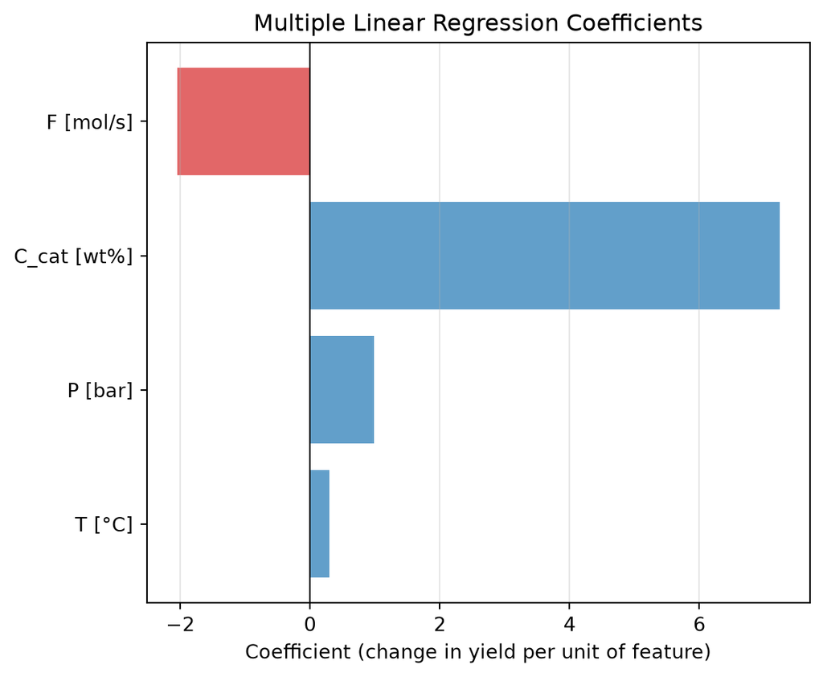

**NoteInterpreting the coefficients**

Each coefficient estimates how much the yield changes for a one-unit increase in that feature, holding the others fixed. Read the **sign** first: temperature, pressure and catalyst concentration are positive (raising them raises yield), while feed flow rate is negative. A higher feed flow means a shorter residence time in the reactor, so less conversion and lower yield, which matches chemical intuition.

Be careful comparing **magnitudes** directly. Because the features have different units and ranges, a larger coefficient does not automatically mean a more important variable. Catalyst concentration has the largest coefficient, but it only ranges from about 0.1 to 1.5 wt%, whereas temperature has a small coefficient yet sweeps from 50 to 200 °C, so temperature still accounts for most of the variation in yield.

**Callout-answer**Answer**

```
plot_coefficients.py
```

```python
def plot_coefficients(model, feature_names):
    """
    Visualise the fitted regression coefficients as a horizontal
    bar chart.

    Parameters
    ----------
    model : fitted regression model
        The trained multiple linear regression model.
    feature_names : list-like
        Names of the input features corresponding to the model
        coefficients.

    Returns
    -------
    None
        Displays a bar chart of the fitted coefficients, with
        positive and negative values shown in different colours.
    """
    coefficients = model.coef_
    colors = ["C0" if c >= 0 else "C3" for c in coefficients]

    plt.figure(figsize=(6, 5))
    plt.barh(feature_names, coefficients, color=colors, alpha=0.7)
    plt.axvline(0, color="k", linewidth=0.8)
    plt.xlabel("Coefficient (change in yield per unit of feature)")
    plt.title("Multiple Linear Regression Coefficients")
    plt.grid(True, alpha=0.3, axis="x")
    plt.tight_layout()
    plt.show()

plot_coefficients(multiple_model, X_train.columns)
```

Output

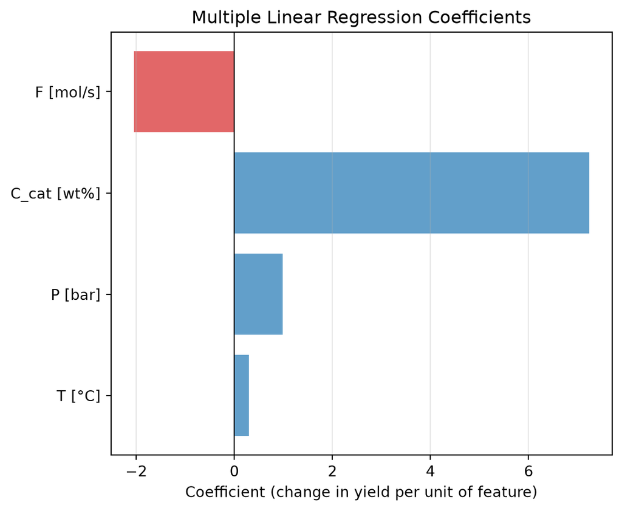

### Task: 12 Model validation using K-Fold cross-validation

**Reuse the `cross_validate_model` function you developed in Part A** to evaluate the multiple linear regression model using **5-fold cross-validation**. This time, use **all four input features** (**T**, **P**, **C_cat**, and **F**) by passing `X_train` to the function rather than a single feature such as `X_train[[feature]]`.

Report the **R²** score for each fold, together with the mean and standard deviation across all folds. Compare the results with those obtained in Part A and comment on whether using all four operating variables improves the model’s predictive performance and consistency.

model=LinearRegression()

cv_scores = cross_validate_model(model, X_train, y_train, cv=5, scoring="r2")

Fold 1: R2 = 0.889

Fold 2: R2 = 0.894

Fold 3: R2 = 0.890

Fold 4: R2 = 0.812

Fold 5: R2 = 0.867

Mean R2: 0.870 +/- 0.030

What does the spread of the scores tell you about the model’s sensitivity to the particular train/test split?

**Callout-answer**Answer**

```
cross_validate_model.py
```

```python
def cross_validate_model(model, X, y, cv=5, scoring="r2"):
    """
    Estimate model performance using k-fold cross-validation.

    Parameters
    ----------
    model : sklearn estimator
        The model to evaluate.
    X : pd.DataFrame
        The feature set.
    y : pd.Series
        The target variable.
    cv : int, optional
        The number of folds (default is 5).
    scoring : str, optional
        The performance metric used to evaluate the model
        (default is "r2").

    Returns
    -------
    scores : np.ndarray
        The cross-validation scores for the chosen metric,
        one value per fold.
    """
    scores = cross_val_score(model, X, y, cv=cv, scoring="r2")

    for i, score in enumerate(scores, start=1):
        print(f"  Fold {i}: R2 = {score:.3f}")
    print(f"Mean R2: {scores.mean():.3f} +/- {scores.std():.3f}")
    return scores

model=LinearRegression()
cv_scores = cross_validate_model(model, X_train, y_train, cv=5, scoring="r2")
```

Output

```
  Fold 1: R2 = 0.889
  Fold 2: R2 = 0.894
  Fold 3: R2 = 0.890
  Fold 4: R2 = 0.812
  Fold 5: R2 = 0.867
Mean R2: 0.870 +/- 0.030
```

The model achieved a mean **R²** of **0.870 ± 0.030**, indicating that the four operating variables together explain approximately **87% of the variability in ethylbenzene yield**. The small standard deviation across the folds shows that the model performs consistently on different subsets of the training data, suggesting that its performance is stable and not strongly dependent on the particular train-validation split.

Compared with the simple linear regression model that used temperature alone, the higher mean **R²** indicates that incorporating pressure, catalyst concentration, and feed flow rate provides additional predictive information. Overall, these results suggest that the multiple linear regression model captures the key factors influencing yield and generalises well across the training dataset.

### Task 13 : Evaluate and compare model performance on the testing set

Now reuse `evaluate_regression` and `plot_actual_vs_predicted` on the multiple regression model, and compare the results against the single-variable model from Part A.

multiple_metrics = evaluate_regression(multiple_model, X_test, y_test)

MAE: 3.401

MSE: 19.754

RMSE: 4.445

R2: 0.905

Which model performs better on the test data, and which metrics support your conclusion?

plot_actual_vs_predicted(multiple_model, X_test, y_test)

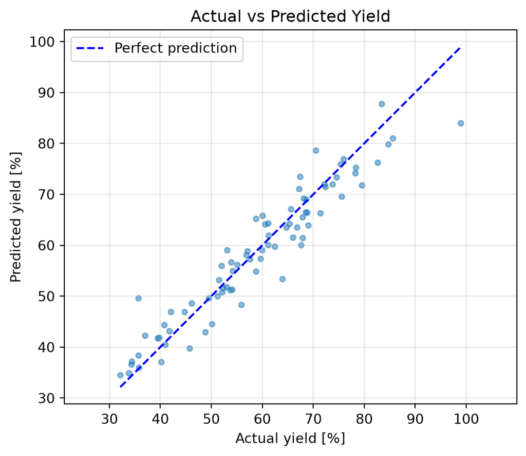

**Callout-answer**Answer**

```python
# Both functions were written in Part A and work unchanged for the four-feature model.
multiple_metrics = evaluate_regression(multiple_model, X_test, y_test)
plot_actual_vs_predicted(multiple_model, X_test, y_test)
```

Output

```
MAE:  3.401
MSE:  19.754
RMSE: 4.445
R2:   0.905
```

Output

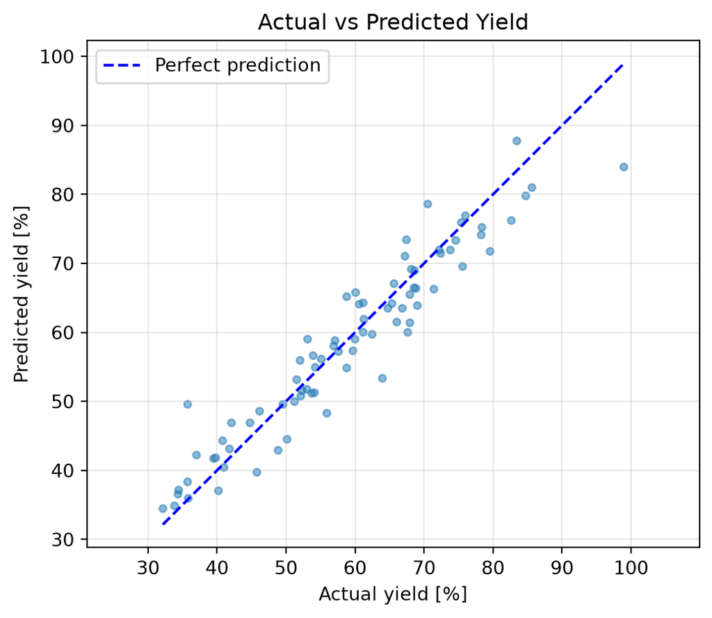

The **multiple linear regression model** performs better on the test data. Its **MAE** decreased from **5.244** to **3.401**, and its **RMSE** decreased from **6.670** to **4.445**, indicating smaller prediction errors. In addition, the **R²** score increased from **0.786** to **0.905**, meaning that the multiple linear regression model explains about **90.5%** of the variation in yield, compared with **78.6%** for the simple linear regression model. These results show that incorporating pressure, catalyst concentration, and feed flow rate alongside temperature substantially improves predictive performance.

### Task: 14 Check the residuals

A model can achieve a high **R²** score and still make systematic errors that are not obvious from the evaluation metrics alone. To investigate this, we can examine the **residuals**, which are the differences between the actual and predicted values:

$$\text{Residual} = y - \hat{y}$$

Write a function `plot_residuals` that creates a scatter plot of the residuals (**actual − predicted**) against the predicted yield for the test set. If the linear regression model is appropriate, the residuals should appear randomly scattered around zero with no clear pattern. Systematic trends, curved shapes, or changes in the spread of the residuals may indicate that the model is missing important relationships in the data.

```
plot_residuals.py
```

```python
def plot_residuals(model, X_test, y_test):
    """
    Plot residuals (actual minus predicted) against the
    predicted values for the test set.

    Parameters
    ----------
    model : fitted regression model
        The trained model to evaluate.
    X_test : pd.DataFrame
        Test features.
    y_test : pd.Series
        True target values for the test set.

    Returns
    -------
    None
        Displays a residual plot.
    """
```

plot_residuals(multiple_model, X_test, y_test)

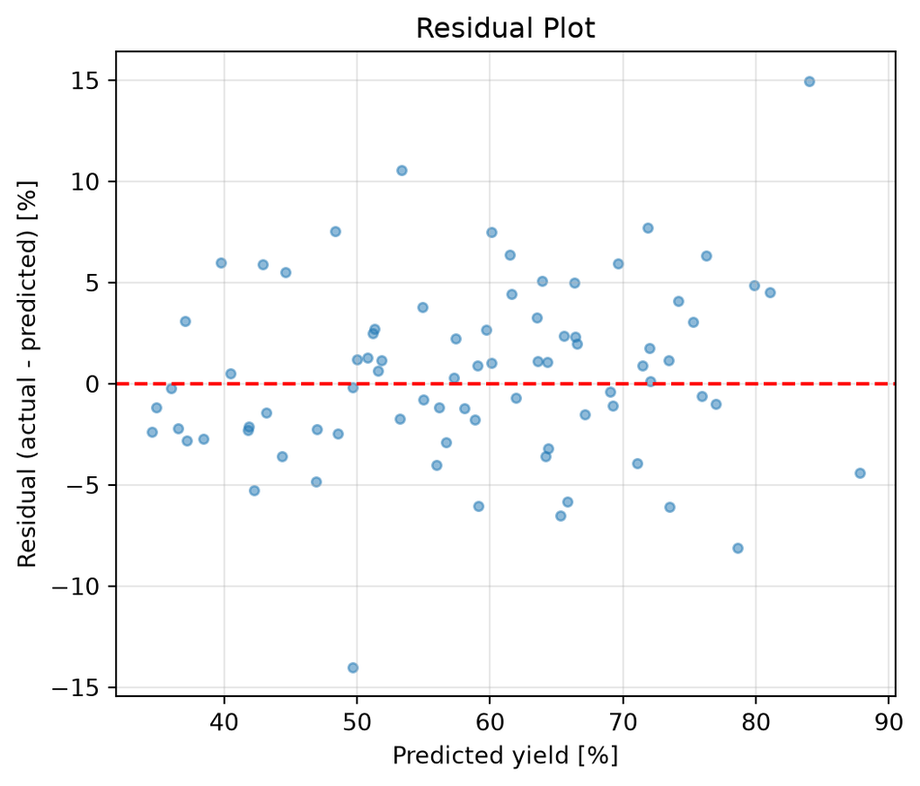

Based on the residual plot, do the residuals appear to be randomly scattered around zero? What does this suggest about the suitability of the multiple linear regression model?

**NoteReading a residual plot**

Plotting residuals against the predicted value is one of the best checks of whether a linear model is appropriate. Ideally the residuals scatter randomly in a horizontal band around zero, with no pattern, which is what we see here. A curve or U-shape would suggest the true relationship is non-linear; a funnel that widens to one side would suggest the size of the error grows with the prediction. The structureless band here supports our choice of a linear model.

**Callout-answer**Answer**

```
plot_residuals.py
```

```python
def plot_residuals(model, X_test, y_test):
    """
    Plot residuals (actual minus predicted) against the
    predicted values for the test set.

    Parameters
    ----------
    model : fitted regression model
        The trained model to evaluate.
    X_test : pd.DataFrame
        Test features.
    y_test : pd.Series
        True target values for the test set.

    Returns
    -------
    None
        Displays a residual plot.
    """
    y_pred = model.predict(X_test)
    residuals = y_test - y_pred

    plt.figure(figsize=(6, 5))
    plt.scatter(y_pred, residuals, alpha=0.5, s=15)
    plt.axhline(0, color="red", linestyle="--")
    plt.xlabel("Predicted yield [%]")
    plt.ylabel("Residual (actual - predicted) [%]")
    plt.title("Residual Plot")
    plt.grid(True, alpha=0.3)
    plt.show()

plot_residuals(multiple_model, X_test, y_test)
```

Output

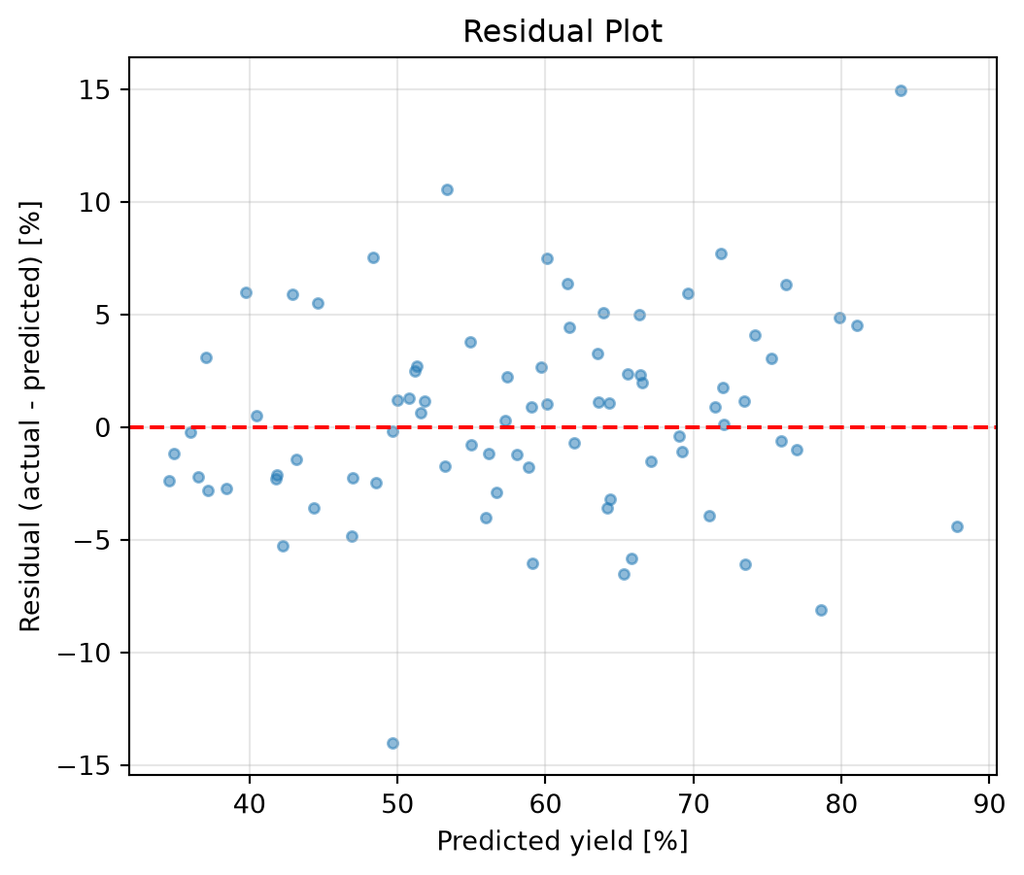

The residuals are generally scattered around the zero line with no obvious trend or curved pattern. This suggests that the linear model captures the main relationships in the data and that the assumptions of linear regression are reasonably satisfied. Although there are a few larger residuals, the overall random scatter indicates that the model is appropriate and does not show strong evidence of systematic prediction errors.

## Conclusion

In this tutorial, you built your first **regression models** to predict a continuous target variable. You started with a **simple linear regression** model using temperature alone, then extended it to a **multiple linear regression** model using all four operating variables, improving the test-set **R²** from about **0.79** to **0.91**. You also learned how to evaluate regression models using **MAE**, **MSE**, **RMSE**, and **R²**, visualise performance with **actual-vs-predicted** and **residual** plots, and use **k-fold cross-validation** to obtain a more reliable estimate of model performance. Finally, you saw how regression coefficients can provide useful process insight by showing how each operating variable affects the predicted yield.

## Sources

- [Scikit-learn documentation](https://scikit-learn.org/stable/documentation.html)
- [Linear Regression](https://scikit-learn.org/stable/modules/linear_model.html#ordinary-least-squares)
- [Regression metrics](https://scikit-learn.org/stable/modules/model_evaluation.html#regression-metrics)
- [Cross-validation](https://scikit-learn.org/stable/modules/cross_validation.html)